# Solution Bernhard’s Task by Dana

This is my attempted solution to Bernhard’s task.

```r
library(readr)
library(tidyverse)

dat <- read_csv2("https://dr-eberle-zentrum.github.io/Advanced-data-processing-with-R/Projects/bernhard-ebersbach/nmin_jena_2022.csv", col_names = TRUE)
```

Then I want to filter only the variables I am interested in. This would be - sowndiv - numleg - ‘Nmin [mg/kg]’ Additionally, we want to recode the variables “numleg” and “sowndiv” in distinct intervals. (Thanks for your help Martin!) Lastly, we are creating the mean of the Variable “Nmin” in order to save this in our final data set for the visualisation.

The code for that is shown below.

```r
edited_dat <- dat |>
select(sowndiv, numleg, `Nmin [mg/kg]`) |>
  mutate(sowndiv = fct_recode(factor(sowndiv),
                         "0-1" = "0",
                         "0-1" = "1",
                         "2-4" = "2",
                         "2-4" = "4",
                         "8-16" = "8",
                         "8-16" = "16",
                         "60" = "60"),
    numleg = fct_recode(factor(numleg),
                        "0-1" = "0",
                        "0-1" = "1",
                        "2-3" = "2",
                        "2-3" = "3",
                        "4-5" = "4",
                        "4-5" = "5",
                        "6-8" = "6",
                        "6-8" = "8",
                        "12" = "12")) |>
  group_by(sowndiv, numleg) |>
  summarize(mean_Nmin = mean(`Nmin [mg/kg]`))
```

With the dataset “edited_dat” I want to attempt to visualize the data set in the way Bernhard wishes for. Lets see how this goes.

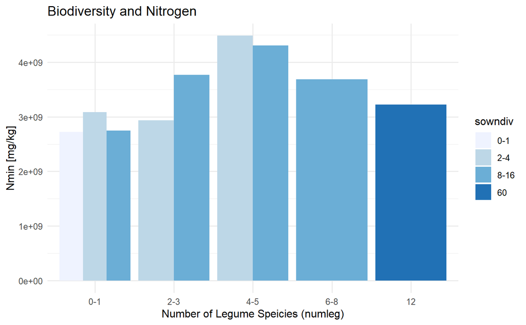

```r
#ggplot(edited_dat) + geom_bar(mapping = aes(y = mean_Nmin, x = numleg,
#                                            color = sowndiv))

ggplot(edited_dat, aes(x = numleg, y = mean_Nmin, fill = sowndiv)) +
   geom_bar(stat = "identity", position = position_dodge()) +
   scale_fill_brewer(palette="Blues") + theme_minimal() +
  labs(y = "Nmin [mg/kg]", x = "Number of Legume Speicies (numleg)",
  title = "Biodiversity and Nitrogen")
```

```r
NA
NA
```

Okay. For some reason which I do not know, my bar plot does not seem to have the same structure as the example picture by Bernhard.

Since I am behind on time, I will leave it as it is for now and continue with the search for a solution.

Open to dos: - Why are there 3 barplots only for the first group of numleg but not for the rest? - label the legend (sowndiv) - hide the numbers for the y-axis - centre the title of the plot

Thank you for reading!

Best, Dana